# Differential gene expression and preliminary ORA

Name: Mengyi Shu  
Student Number: 1004553636

Install packages:

```r
if (!requireNamespace("BiocManager", quietly = TRUE))
  install.packages("BiocManager")
if (!requireNamespace("GEOmetadb", quietly = TRUE))
  BiocManager::install("GEOmetadb")
if(!requireNamespace("edgeR", quietly = TRUE))
  BiocManager::install("edgeR")
if(!requireNamespace("biomaRt", quietly = TRUE))
  BiocManager::install("biomaRt")
if(!requireNamespace("ComplexHeatmap", quietly = TRUE))
  BiocManager::install("ComplexHeatmap")
if(!requireNamespace("circlize", quietly = TRUE))
  install.packages("circlize")
library(GEOmetadb)
library(edgeR)
library(biomaRt)
library(ComplexHeatmap)
library(circlize)
```

# Preparation:Normalized expression set from Assignment #1

### Loading data

Data was downloaded from GEO with id GSE160499. This data set contain AML pateints and divided into 2 groups, one group with high Nrf2 expression and one with low Nrf2 expression

```r
# Set GSEMatrix to FALSE to get other columns from the GSE records
gse <- getGEO("GSE160499", GSEMatrix=FALSE)
# Get platform info from GSE160499
current_gpl <- names(GPLList(gse))[1]
current_gpl_info <- Meta(getGEO(current_gpl))
# Get expression data (gene raw counts) from supplementary files
supp_files = getGEOSuppFiles('GSE160499')
file_names = rownames(supp_files)
# There is only one supplemental file
# Set check.names to false so the column names are not automatically reformatted
Nrf2_exp = read.delim(file_names[1], header=TRUE, check.names=FALSE)
```

### Define Sample Groups

Since the experiment divided AML patients into 2 groups either expressing high or low levels of Nrf2.I classified patients into 2 groups:L represent low expression and H represent high expression.

```r
#Extract patient information
Patient <- colnames(Nrf2_exp)[2:8]
#extract type of patient cell,L stand for the patient that expresse low level of Nrf2 and H represent patients with high level of Nrf2
CellTypes<-c("L","L","L","H","H","H","H")
sample <- data.frame(Patient,CellTypes)
```

### Filtering data

No duplicated genes were discovered in the dataset.

Genes with low counts are filtered out.

```r
#translate out counts into counts per million using
#the edgeR package function cpm
cpms = edgeR::cpm(Nrf2_exp[,2:8])
rownames(cpms) <- Nrf2_exp[,1]
# get rid of low counts
keep = rowSums(cpms >1) >=3
Nrf2_exp_filtered = Nrf2_exp[keep,]
# Transform dataframe counts to matrix
filtered_data_matrix <- as.matrix(Nrf2_exp_filtered[, 2:8])
rownames(filtered_data_matrix) <- Nrf2_exp_filtered$AccID
```

**Number of removed genes**: 39609  
**Number of remaining genes**: 14652

### Normalization results

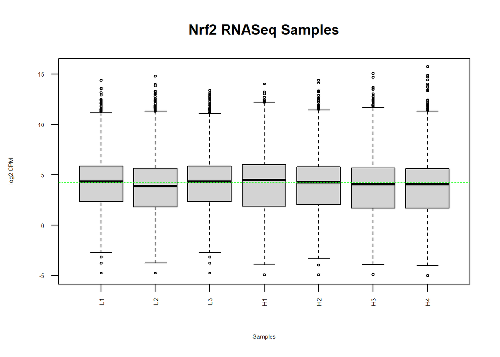

```r
data2plot <- log2(edgeR::cpm(Nrf2_exp_filtered[,2:8]))
boxplot(data2plot, xlab = "Samples", ylab = "log2 CPM",
        las = 2, cex = 0.5, cex.lab = 0.5,
        cex.axis = 0.5, main = "Nrf2 RNASeq Samples")
#draw the median on each box plot
abline(h = median(apply(data2plot, 2, median)),
       col = "green", lwd = 0.6, lty = "dashed")
```

**FIGURE 1. BOXPLOT of post-nomalization.**

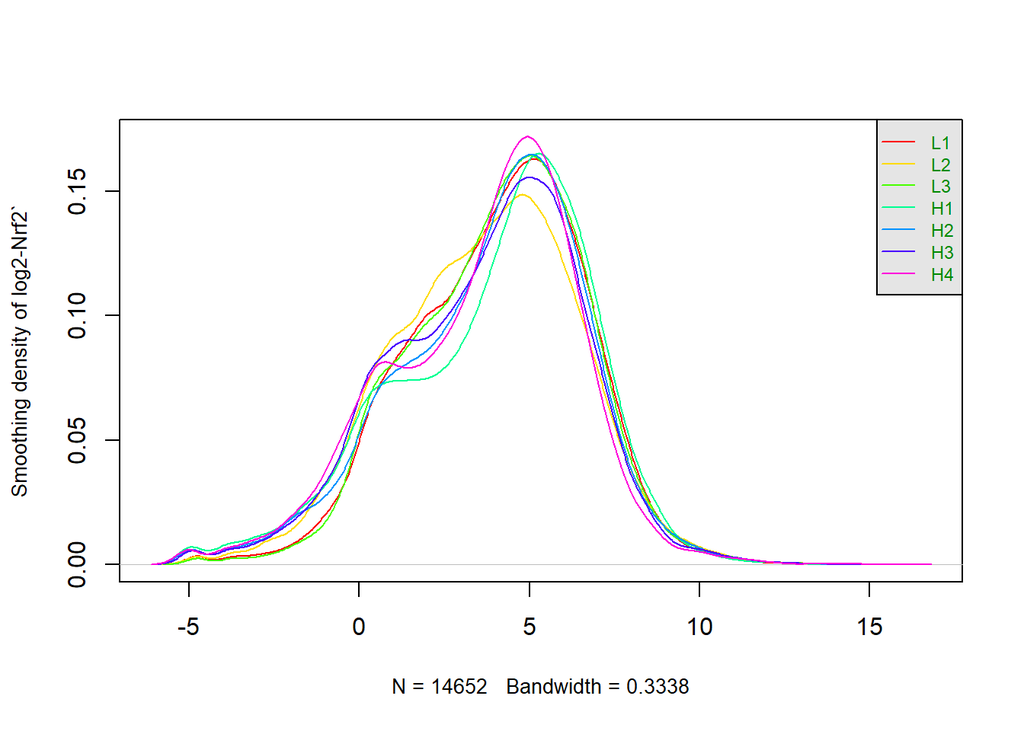

```r
counts_density <- apply(log2(edgeR::cpm(Nrf2_exp_filtered[,2:8])),
                        2, density)
  #calculate the limits across all the samples
    xlim <- 0; ylim <- 0
    for (i in 1:length(counts_density)) {
      xlim <- range(c(xlim, counts_density[[i]]$x));
      ylim <- range(c(ylim, counts_density[[i]]$y))
    }
    cols <- rainbow(length(counts_density))
    ltys <- rep(1, length(counts_density))
    #plot the first density plot to initialize the plot
    plot(counts_density[[1]], xlim=xlim, ylim=ylim, type="n",
         ylab="Smoothing density of log2-Nrf2`",
         main="", cex.lab = 0.85)
    #plot each line
    for (i in 1:length(counts_density))
      lines(counts_density[[i]], col=cols[i], lty=ltys[i])
    #create legend
    legend("topright", colnames(data2plot),
           col=cols, lty=ltys, cex=0.75,
           border ="blue",  text.col = "green4",
           merge = TRUE, bg = "gray90")
```

**FIGURE 2. Density Plot of post-nomalization.**

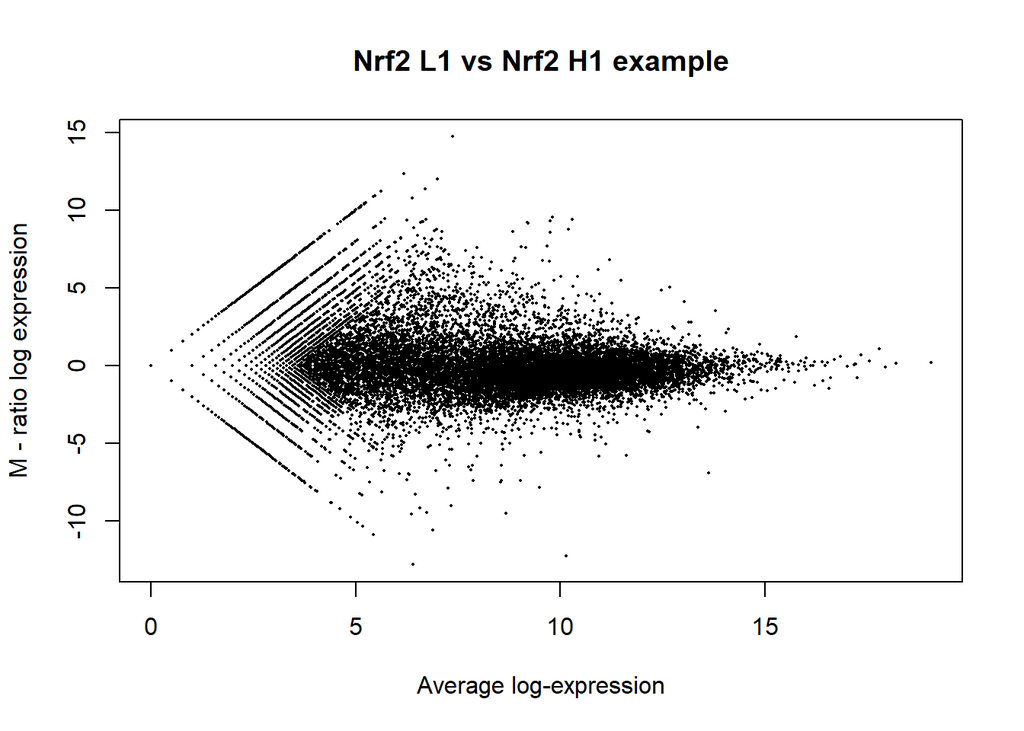

```r
plotMA(log2(Nrf2_exp[,c(2,5)]), ylab="M - ratio log expression",
       main="Nrf2 L1 vs Nrf2 H1 example")
```

### Applying TMM to our dataset

create an edgeR container for RNASeq count data

```r
celltypes <-colnames(Nrf2_exp)[2:8]
filtered_data_matrix <- as.matrix(Nrf2_exp_filtered[,2:8])
rownames(filtered_data_matrix) <- Nrf2_exp_filtered$AccID
d = edgeR::DGEList(counts=filtered_data_matrix, group=sample$CellTypes)
```

### Calculate the normalization factors

```r
d = edgeR::calcNormFactors(d)
```

#### Get normalized data

```r
#get the normalized data
normalized_counts <- edgeR::cpm(d)
```

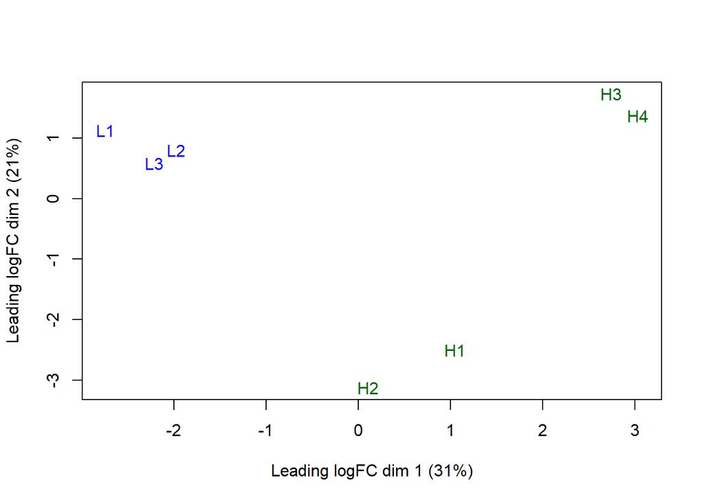

```r
plotMDS(d, labels=celltypes,
  col = c("darkgreen","blue")[factor(sample$CellTypes)])
```

**FIGURE 4. MDS Plot of post-normalization.**

#### Identifying mapping

```r
#Connect to the desired mart
ensembl <- useMart("ensembl")
```

```r
#Get the set of datasets available
datasets <- listDatasets(ensembl)
knitr::kable(head(datasets),format = "html")
```

| dataset | description | version |
| --- | --- | --- |
| abrachyrhynchus_gene_ensembl | Pink-footed goose genes (ASM259213v1) | ASM259213v1 |
| acalliptera_gene_ensembl | Eastern happy genes (fAstCal1.2) | fAstCal1.2 |
| acarolinensis_gene_ensembl | Green anole genes (AnoCar2.0v2) | AnoCar2.0v2 |
| acchrysaetos_gene_ensembl | Golden eagle genes (bAquChr1.2) | bAquChr1.2 |
| acitrinellus_gene_ensembl | Midas cichlid genes (Midas_v5) | Midas_v5 |
| amelanoleuca_gene_ensembl | Giant panda genes (ASM200744v2) | ASM200744v2 |

```r
#Limit to the human datasets available
knitr::kable(head(datasets[grep(datasets$dataset,
                  pattern = "sapiens"),]),format = "html")
```

|  | dataset | description | version |
| --- | --- | --- | --- |
| 80 | hsapiens_gene_ensembl | Human genes (GRCh38.p13) | GRCh38.p13 |

```r
ensembl = useDataset("hsapiens_gene_ensembl",mart=ensembl)
```

#### Building a Biomart Query

We are trying to convert Human Ensembl Gene Ids to HGNC symbols

```r
#how many filters are there?
dim(listFilters(ensembl))
```

```
## [1] 439   2
```

```r
knitr::kable(listFilters(ensembl)[1:10,1:2], type="html")
```

| name | description |
| --- | --- |
| chromosome_name | Chromosome/scaffold name |
| start | Start |
| end | End |
| strand | Strand |
| chromosomal_region | e.g. 1:100:10000:-1, 1:100000:200000:1 |
| with_biogrid | With BioGRID Interaction data, The General Repository for Interaction Datasets ID(s) |
| with_ccds | With CCDS ID(s) |
| with_chembl | With ChEMBL ID(s) |
| with_dbass3 | With DataBase of Aberrant 3’ Splice Sites ID(s) |
| with_dbass5 | With DataBase of Aberrant 5’ Splice Sites ID(s) |

```r
biomart_human_filters <- listFilters(ensembl)
knitr::kable(biomart_human_filters[
  grep(biomart_human_filters$name,pattern="ensembl"),],
      format="html")
```

|  | name | description |
| --- | --- | --- |
| 51 | ensembl_gene_id | Gene stable ID(s) [e.g. ENSG00000000003] |
| 52 | ensembl_gene_id_version | Gene stable ID(s) with version [e.g. ENSG00000000003.15] |
| 53 | ensembl_transcript_id | Transcript stable ID(s) [e.g. ENST00000000233] |
| 54 | ensembl_transcript_id_version | Transcript stable ID(s) with version [e.g. ENST00000000233.10] |
| 55 | ensembl_peptide_id | Protein stable ID(s) [e.g. ENSP00000000233] |
| 56 | ensembl_peptide_id_version | Protein stable ID(s) with version [e.g. ENSP00000000233.5] |
| 57 | ensembl_exon_id | Exon ID(s) [e.g. ENSE00000000003] |

#### Attributes

```r
knitr::kable(listAttributes(ensembl)[1:10,1:2], type="html")
```

| name | description |
| --- | --- |
| ensembl_gene_id | Gene stable ID |
| ensembl_gene_id_version | Gene stable ID version |
| ensembl_transcript_id | Transcript stable ID |
| ensembl_transcript_id_version | Transcript stable ID version |
| ensembl_peptide_id | Protein stable ID |
| ensembl_peptide_id_version | Protein stable ID version |
| ensembl_exon_id | Exon stable ID |
| description | Gene description |
| chromosome_name | Chromosome/scaffold name |
| start_position | Gene start (bp) |

```r
conversion_stash <- "Nrf2_id_conversion.rds"
if(file.exists(conversion_stash)){
  Nrf2_id_conversion <- readRDS(conversion_stash)
} else {
  Nrf2_id_conversion <- getBM(attributes = c("ensembl_gene_id","hgnc_symbol"),
                            filters = c("hgnc_symbol"),
                            values = Nrf2_exp_filtered$AccID,
                            mart = ensembl)
  saveRDS(Nrf2_id_conversion, conversion_stash)
}
```

# Differential gene expression analysis

I analyzed differential expression of genes separately for the AML patients with high Nrf2 expression and low Nrf2 expression.The goal for calculating p values is to etermine the underlying relationship between poor versus good gene signatures for identifying biological functions or predicting specific therapeutic outcomes.In this case, we want to compare the difference in gene signatures of Nrf2 overexpression patients versus lower expression of Nrf2 patiesnts

### Calculating p-values and multiple hypothesis testing.

Calculating p-values for the AML patients with high Nrf2 expression and low Nrf2 expression: For multiple hypothesis correction, I used Benjamini-Hochberg procedure which is standard way to decrease false discovery rate. I set the p-value threshold to 0.05 since it is a standard statistics that a fact is happened by chance

```r
# Create a container for expression count data
data = DGEList(counts=filtered_data_matrix, group=sample$CellTypes)
# Create model
model_design_pat <- model.matrix(~ sample$CellTypes)
#estimate dispersion
data <- estimateDisp(data, model_design_pat)
#calculate normalization factors
data <- calcNormFactors(data)
#fit model
fit <- glmQLFit(data, model_design_pat)
#calculate differential expression
qlf <- glmQLFTest(fit)
qlf_hits <- topTags(qlf, sort.by = "PValue", adjust.method = "BH", n = nrow(filtered_data_matrix))
```

**Number of genes pass p < 0.05 in 2 groups of AML patients**: 3227  
**Number of genes pass correction in 2 groups of AML patients**: 46  
**Number of up-regulated genes in 2 groups of AML patients**: 42  
**Number of down-regulated genes in 2 groups of AML patients**: 4

### Volcano plot

Build volcano plot:

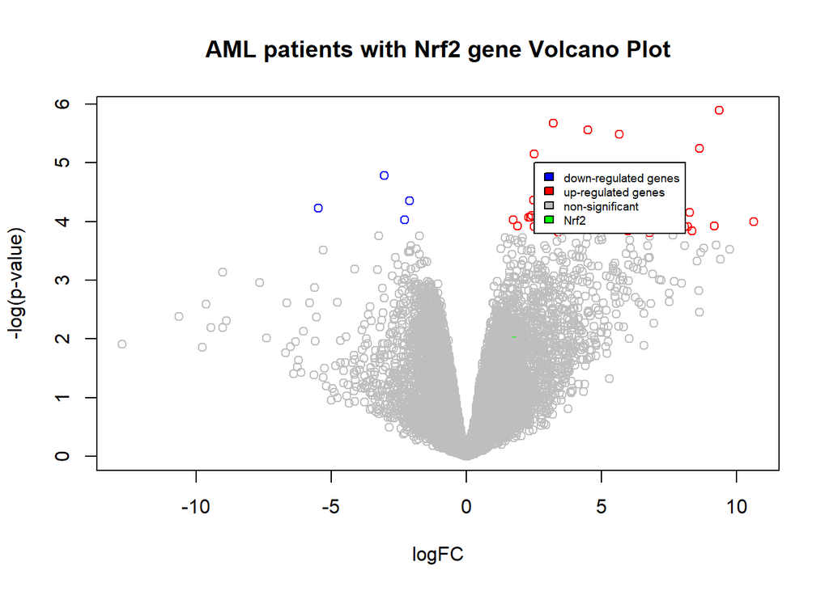

Volcano plot for AML patient

```r
# Assign colours to genes: up-regulated is red, down-regulated is blue
colours <- vector(mode="character", length=nrow(qlf_hits))
colours[] <- 'grey'
colours[qlf_hits$table$logFC < 0 & qlf_hits$table$FDR < 0.05] <- 'blue'
colours[qlf_hits$table$logFC > 0 & qlf_hits$table$FDR < 0.05] <- 'red'
colours[row.names(qlf_hits) == "NFE2L2"] <- 'green'
# Make plot
plot(qlf_hits$table$logFC,
     -log(qlf_hits$table$PValue, base=10),
     col = colours,
     xlab = "logFC",
     ylab ="-log(p-value)",
     main="AML patients with Nrf2 gene Volcano Plot")
# Create legend
legend(2.5, 5, legend=c("down-regulated genes","up-regulated genes", "non-significant", "Nrf2"),
       fill = c("blue", "red", "grey", "green"), cex = 0.6)
```

### Heat map

Create heat map:

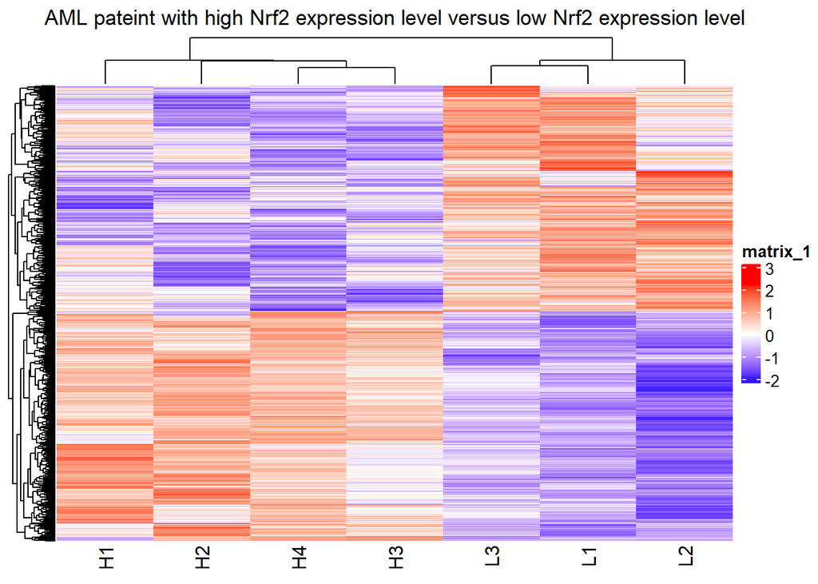

Heat map for high Nrf2 AML patients versus low Nrf2 AML patients

```r
# Get top hit gene names
top_hits <- rownames(qlf_hits)[qlf_hits$table$PValue < 0.05]
# Calculate logCPM
hm_matrix <- log2(filtered_data_matrix[, 1:7] +1)
# Scale heat map matrix by rows
hm_matrix_top <- t(scale(t(hm_matrix[rownames(hm_matrix) %in% top_hits, ])))
# Create color ramps
if(min(hm_matrix_top) == 0){
    heatmap_col = colorRamp2(c( 0, max(hm_matrix_top)),
                             c( "white", "red"))
  } else {
    heatmap_col = colorRamp2(c(min(hm_matrix_top), 0, max(hm_matrix_top)), c("blue", "white", "red"))
  }
# Create heatmap
Heatmap(as.matrix(hm_matrix_top),
        cluster_rows = TRUE, show_row_dend = TRUE,
        cluster_columns = TRUE, show_column_dend = TRUE,
        col=heatmap_col, show_column_names = TRUE,
        show_row_names = FALSE, show_heatmap_legend = TRUE,
        column_title = "AML pateint with high Nrf2 expression level versus low Nrf2 expression level")
```

From the heat map,the patients with high Nrf2 expression are clustered together(H1,H2,H3,H4) and patients with low Nrf2 expression are clustered together(L1,L2). I There is a clear contrast between different conditions as shown in heat map.Even though there are small heterogeneity between individual but the overall pattern is similar within each group. They cluster together because as indicated in paper Nrf2 expression is associated with tumor mutation burden in AML,therefore AML patients with different expression level should have different pattern.

# Thresholded over-representation analysis

### Creating thresholded list of genes

I choose to use a thresholded list of genes to perform Gene List Enrichment Analysis which is a statistical method that determines whether genes from pre-defined sets(in this case the pathways in gprofiles) are present more than would be expected (over-represented) in a subset of data below. The annotation data I used is Reactome, Go biologoical process, and Wiki pathways, the version is :e105_eg52_p16_e84549f I used these three dataset becuase this three is very comprehensive data set of human pathways

```r
# Create separate tables of up- and down-regulated genes
upreg_genes <- row.names(qlf_hits)[
  which(qlf_hits$table$FDR < 0.05 & qlf_hits$table$logFC > 0)]
downreg_genes <- row.names(qlf_hits)[
  which(qlf_hits$table$FDR < 0.05 & qlf_hits$table$logFC < 0)]

# Write tables to files
write.table(x=upreg_genes,
            "./gene_list/Nrf2_upregulated_genes.txt",sep='\t',
            row.names = FALSE,col.names = FALSE,quote = FALSE)
write.table(x=downreg_genes,
            "./gene_list/Nrf2_downregulated_genes.txt",sep='\t',
            row.names = FALSE,col.names = FALSE,quote = FALSE)
```

### G:Profiler analysis on thresholded gene lists

I used G:Profiler because it is a suitable method for analyzing over-representation in thresholded gene list which do not require ranked list. We also had some experience working with G:Profiler because we have relative exprience and more familira with it(the homework).

All G:Profiler queries were run using the following parameters:

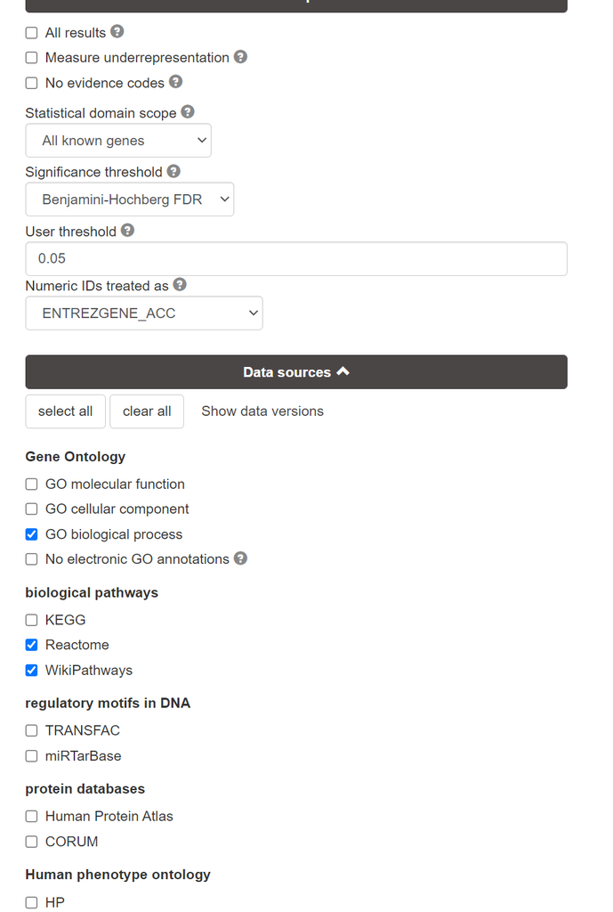

G:Profiler parameters for running Nrf2 experiment differentially expressed genes

For all below analyses on terms, I set the term size range to 1-300.

#### Over-representation analysis

**Results using the whole list (both up- and down-regulated genes):**

- Without limiting the term size, there are 514 terms (genesets) from GO:BP, 33 from Reactome, and 3 from WikiPathways, with a p-value threshold of 0.05.
- Result from GO BP shows that many differentially expressed genes in AML patients are involved in :

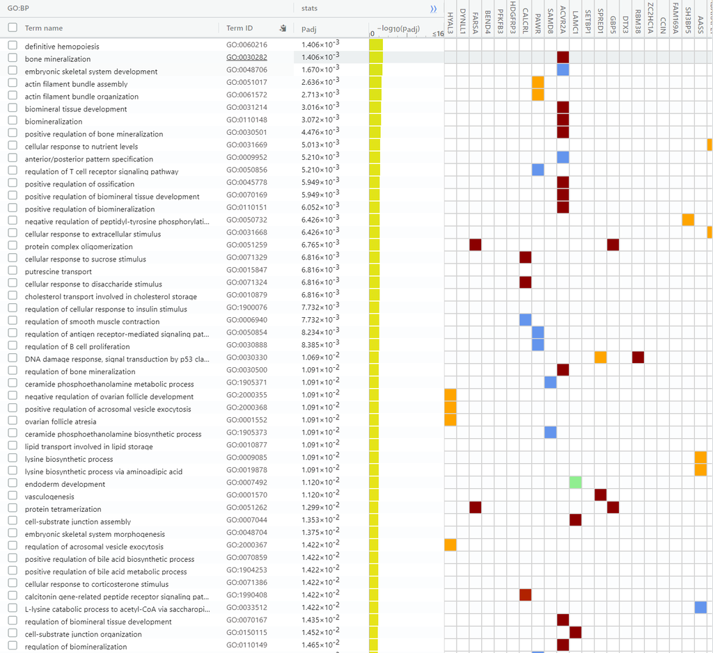

AML patients with all genes over-representation analysis results from GO: BP, term size = 300

- Result from Reactome is similar to terms from GO BP:

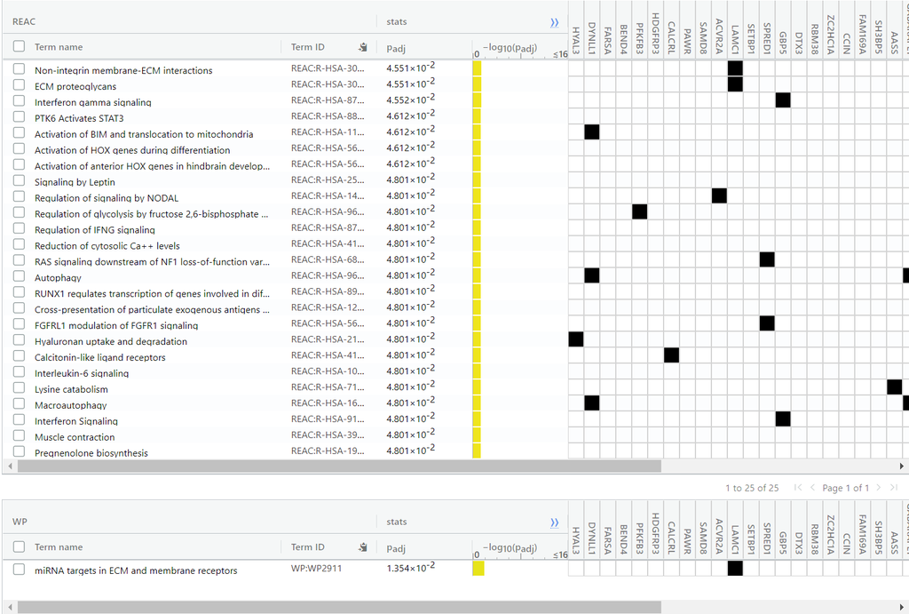

**Results using the up-regulated genes:**

- When I do not limit the term size, there are 535 terms (genesets) from GO:BP, 29 from Reactome, and 4 from WikiPathways, with a p-value threshold of 0.05.
- Result from GO BP shows that many differential expressed genes in AML patients are involved in bone mineralization,definitive hemopoiesis,and embryonic skeletal system development.Result for Reactome shows that many genes are related to ECM interaction and transportation,interferon gamma signaling and muscle contraction.For wiki pathway,gene sets involved miRNA targets in ECM and membrane receptors,Focal adhesion: PI3K-Akt-mTOR-signaling pathway,this is a pathway involves in intracellular signaling pathway involved in numerous biological processes such as cell proliferation and apoptosis, angiogenesis, and glucose metabolism.

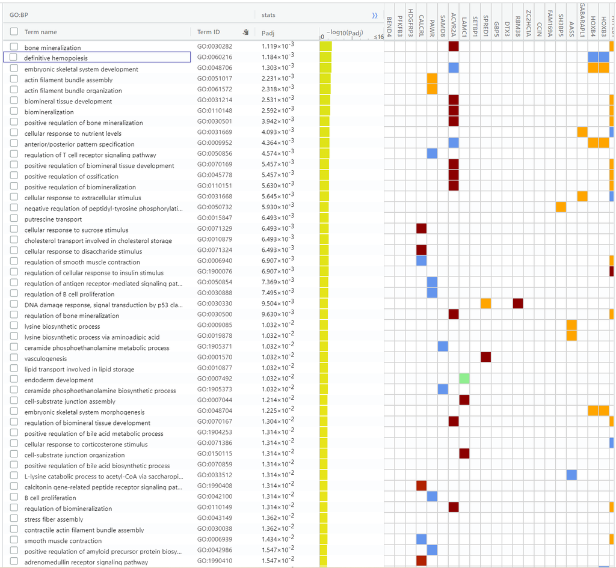

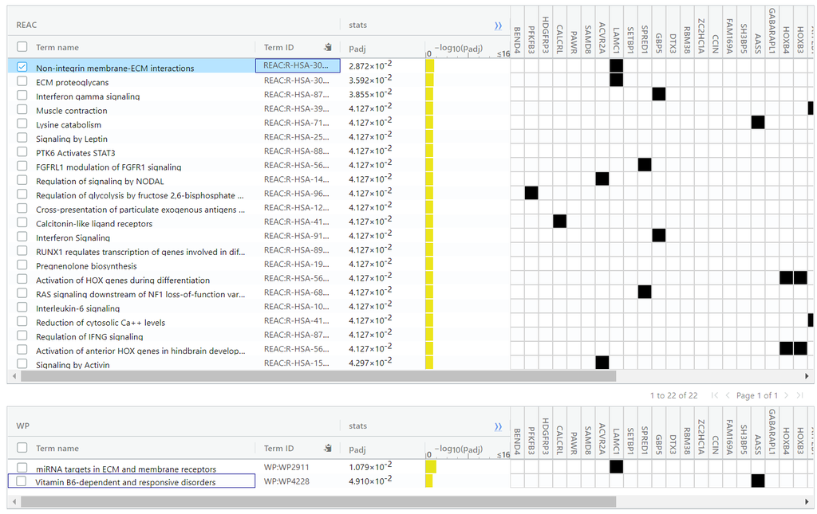

AML patients with upregulated genes over-representation analysis results from REACTOME and wiki, term size = 300

**Results using the down-regulated genes:**

- When I do not limit the term size, there are 13 terms (genesets) from GO:BP, 0 from Reactome, and 5 from WikiPathways, with a p-value threshold of 0.05.
- The top terms result from GO BP are gene set about regulation of transportation and regulation of translation such as acrosomal vesicle exocytosis ,phenylalanyl-tRNA aminoacylation.The top terms result from WP is related to molecule movement and tranportation such as Intraflagellar transport proteins binding to dynein pathway and Vasopressin-regulated water reabsorption.

[figure not shown]

AML patients with downregulated genes over-representation analysis results from GO: BP,REAC and wiki, term size = 300

## Questions

**How do these results compare to using the whole list (i.e all differentially expressed genes together vs. the up-regulated and down regulated differentially expressed genes separately)?**

# Interpretation

**Do the over-representation results support conclusions or mechanism discussed in the original paper?**

**Can you find evidence, i.e. publications, to support some of the results that you see. How does this evidence support your results.**  
In the upregulating over-representing analysis result, there are many structural gene such as genes that involves in ECM. In Izzi et.al(2017)’s paper indicates that acute leukemia will change the microenvironment and give rise to leukemia clones.ECM genes played significant roles in shaping the stromal cell-derived extracellular matrix environment for lukemia stem cell that is suitable for give rise to leukemia stem cells.There are around 80 ECM genes are cahracteristizes as leukemia cells.

# Citations

Izzi, V., Heljasvaara, R., & Pihlajaniemi, T. (2017). Understanding the extracellular matrix in acute myeloid leukemia. Haematologica, 102(11), 1807–1809. https://doi.org/10.3324/haematol.2017.174847

Liu P, Ma D, Wang P, Pan C, Fang Q, Wang J. Nrf2 overexpression increases risk of high tumor mutation burden in acute myeloid leukemia by inhibiting MSH2. Cell Death Dis. 2021 Jan 5;12(1):20. doi: 10.1038/s41419-020-03331-x. PMID: 33414469; PMCID: PMC7790830.

Isserlin R (2022). “BCB420 lectures”. University of Toronto.

Zhu Y, Davis S, Stephens R, Meltzer PS, Chen Y (2008). “GEOmetadb: powerful alternative search engine for the Gene Expression Omnibus.” Bioinformatics (Oxford, England), 24(23), 2798–2800. ISSN 1367-4811, doi: 10.1093/bioinformatics/btn520

Chen Y, Lun AAT, Smyth GK (2016). “From reads to genes to pathways: differential expression analysis of RNA-Seq experiments using Rsubread and the edgeR quasi-likelihood pipeline.” F1000Research, 5, 1438. doi: 10.12688/f1000research.8987.2.